# R Notebook

Notebook for analyses for reviewers/revision of the manuscript. Notebook 1: Obtaining P-values from elpd_diff Note: anpan works in a bayesian framework, where P-values are not a common metric. The phylogenetic effect (sigma_phylo) is already regularized in the model, which should control for false discoveries (see below for more info).

```r
set.seed(12234)
library(tidyverse)
library(patchwork)
setwd("/mnt/project/Make_Associations/Git/PhylogeneticAssociation/Analyses_revision")
```

## Assuming that epld_loo follows a normal distribution, obtain a T-value and a P-value for it

```r
#Read table of elpd statistics
#Europe
read_csv("../../../Association/Results_PerContinent_Europe.csv") %>% mutate(Continent="Europe") -> Europe
#Asia
read_csv("../../../Association/Results_PerContinent_Asia.csv") %>% mutate(Continent="Asia") -> Asia
#NorthAmerica
read_csv("../../../Association/Results_PerContinent_NorthAmerica.csv") %>% mutate(Continent="North_America") -> NorthAmerica
#SouthAmerica
read_csv("../../../Association/Results_PerContinent_SouthAmerica.csv") %>% mutate(Continent="South_America") -> SouthAmerica
#Africa
read_csv("../../../Association/Results_PerContinent_Africa.csv") %>% mutate(Continent="Africa") -> Africa
#Oceania
read_csv("../../../Association/Results_PerContinent_Oceania.csv") %>% mutate(Continent="Oceania") -> Oceania
##Merge
Europe %>% rbind(Asia) %>% rbind(NorthAmerica) %>% rbind(SouthAmerica) %>% rbind(Africa) %>% rbind(Oceania) -> df
print(dim(df))
```

```
## [1] 3317   21
```

Compute P-values

```r
T_stat_P = function(T_value){
  p_value <- 2 * (1 - pnorm(abs(T_value)))
}
###Compute T-statostic, P-value and Q-value
df %>% mutate(T_stat = elpd_diff/se_diff, P_value = T_stat_P(T_stat), P_bonferroni = P_value*dim(df)[1], FDR=p.adjust(P_value, "fdr")  ) -> df
```

Compute cut-off used in manuscript

```r
df %>% mutate( Percentage_badk = 100* ( (k_bad+k_verybad)/(k_good+k_ok+k_bad+k_verybad))  ) -> df
df %>% mutate(Cutoff = ifelse(  Abs_LowerBound > 0 & elpd_diff < -4 & Percentage_badk < 1, T, F) ) -> df
```

Compare P_bonferroni with the cut-off applied in the manuscript

```r
df %>% group_by(P_bonferroni < 0.05, Cutoff==T ) %>% summarise(N = n()) %>% print()
```

```
## # A tibble: 4 × 3
## # Groups:   P_bonferroni < 0.05 [2]
##   `P_bonferroni < 0.05` `Cutoff == T`     N
##   <lgl>                 <lgl>         <int>
## 1 FALSE                 FALSE          2772
## 2 FALSE                 TRUE            363
## 3 TRUE                  FALSE            60
## 4 TRUE                  TRUE            122
```

Compare FDR with the cut-off applied in the mansucript

```r
df %>% group_by(FDR < 0.05, Cutoff==T ) %>% summarise(N = n()) %>% print()
```

```
## # A tibble: 4 × 3
## # Groups:   FDR < 0.05 [2]
##   `FDR < 0.05` `Cutoff == T`     N
##   <lgl>        <lgl>         <int>
## 1 FALSE        FALSE          2611
## 2 FALSE        TRUE            172
## 3 TRUE         FALSE           221
## 4 TRUE         TRUE            313
```

Reproduce supplementary figure 3A with different cut-offs

```r
read_tsv("/mnt/project/Make_Associations/Phenotypes/Phenotypic_categories.tsv") %>% rename(Phenotype = Phenos) -> Categories
```

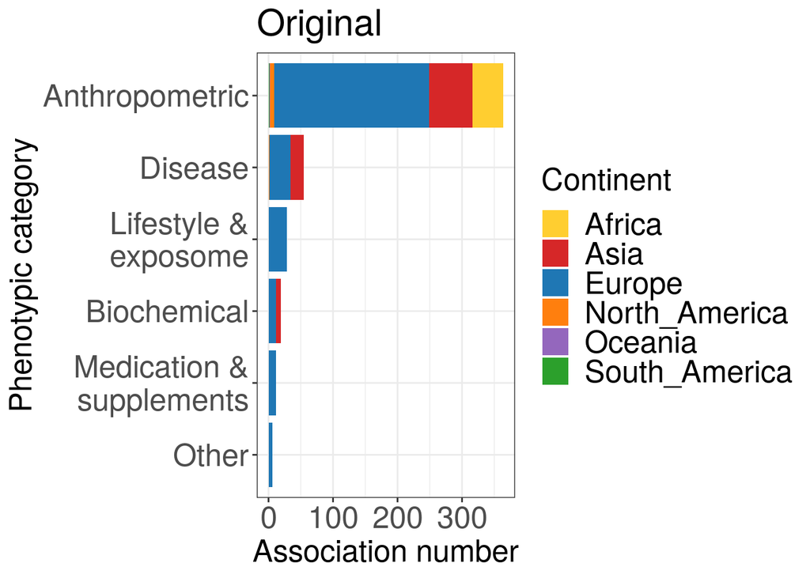

```r
Make_SF3A=  function(All_associations, Phenotypic_categories= Categories){
  All_associations %>% group_by(Phenotype, Continent) %>% summarise(N = n()) %>% spread(Continent, N) %>% ungroup() -> N_phenotypes
  N_phenotypes[is.na(N_phenotypes)] = 0
  N_phenotypes %>% left_join(Categories) %>% select(-Phenotype) %>% group_by(Category) %>%
  summarise_all(sum) %>% gather(Continent, N_associations,Africa:South_America) %>% mutate(Category = ifelse(Category == "Lifestyle_and_exposome", "Lifestyle &\nexposome", ifelse(Category == "Medication_and_Supplements", "Medication &\n supplements",  Category) ) ) %>% drop_na() %>%
  ggplot(aes(x=reorder(Category, N_associations), y=N_associations, fill=Continent )) + geom_bar(stat="identity") + theme_bw() +
  scale_fill_manual(values=c("Europe" = "#1f77b4", "North_America" = "#ff7f0e", "South_America" = "#2ca02c", "Asia" = "#d62728", "Oceania" = "#9467bd", "Africa" = "#FFCE30")) + coord_flip() +
  xlab("Phenotypic category") + theme(
    text = element_text(size = 19), # Adjust the text size as needed
    axis.text.x = element_text(size = 19), # Text size for x-axis labels
    axis.text.y = element_text(size = 19), # Text size for y-axis labels
    legend.text = element_text(size = 19) # Text size for legend
  ) + ylab("Association number") -> Plot1
  return(Plot1)
}


Make_SF3A( df %>% filter(Cutoff == T) ) + ggtitle("Original")
```

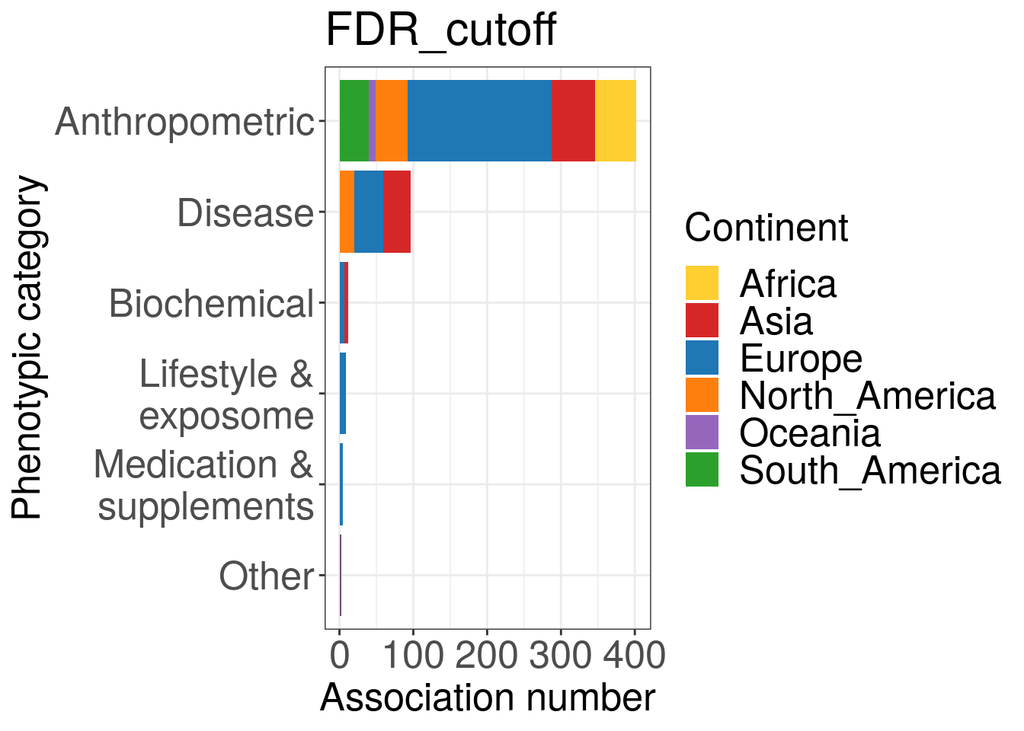

```r
Make_SF3A( df %>% filter(FDR < 0.05 ) ) + ggtitle("FDR_cutoff")
```

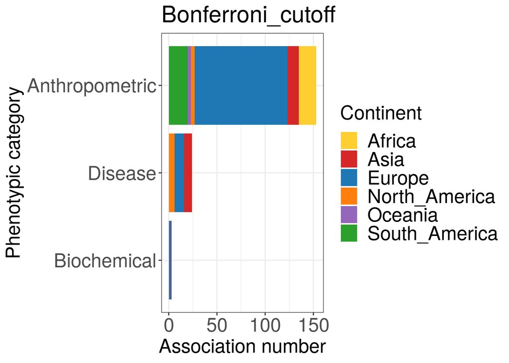

```r
Make_SF3A( df %>% filter(P_bonferroni < 0.05 ) ) + ggtitle("Bonferroni_cutoff")
```

Are the major examples of the manuscript not significant on a different cut-off?

```r
#B. longum and age
df %>% filter(SGB == "t__SGB17248") %>% filter(Phenotype == "Age") %>% filter(Continent %in% c("Europe", "Africa") ) %>% select(Continent, elpd_diff, P_bonferroni, FDR ,Cutoff )
```

| Continent | elpd_diff | P_bonferroni | FDR | Cutoff |
| --- | --- | --- | --- | --- |
| Europe | -412.139532 | 0.0000 | 0.00000000 | TRUE |
| Africa | -8.026457 | 44.6686 | 0.07358912 | TRUE |

```r
#R. gnavus and age
df %>% filter(SGB == "t__SGB4584") %>% filter(Phenotype == "Age") %>% filter(Continent %in% c("Europe", "Asia") ) %>% select(Continent, elpd_diff, P_bonferroni, FDR ,Cutoff )
```

| Continent | elpd_diff | P_bonferroni | FDR | Cutoff |
| --- | --- | --- | --- | --- |
| Europe | -34.99214 | 0.61756691 | 0.0024409759 | TRUE |
| Asia | -55.64166 | 0.06688632 | 0.0003538959 | TRUE |

```r
#R. bromii and BMI
df %>% filter(SGB == "t__SGB4285_group") %>% filter(Phenotype == "BMI") %>% filter(Continent %in% c("Europe", "Asia", "NorthAmerica") ) %>% select(Continent, elpd_diff, P_bonferroni, FDR ,Cutoff )
```

| Continent | elpd_diff | P_bonferroni | FDR | Cutoff |
| --- | --- | --- | --- | --- |
| Europe | -24.80258 | 0.6982507 | 0.002706398 | TRUE |
| Asia | -0.59798 | 355.5974403 | 0.294368742 | FALSE |

```r
#C. aerofaciens and melanoma
df %>% filter(SGB == "t__SGB14546_group") %>% filter(Phenotype == "melanoma") %>% filter(Continent %in% c("Europe", "NorthAmerica") ) %>% select(Continent, elpd_diff, P_bonferroni, FDR ,Cutoff )
```

| Continent | elpd_diff | P_bonferroni | FDR | Cutoff |
| --- | --- | --- | --- | --- |
| Europe | -140.9022 | 3.535305e-11 | 7.36522e-13 | TRUE |

Reviewer 1 is further interested in the P-values of nonagenarian associations (L246++ in the orginal manuscript). Which correspond to SGB4584/Ruminococcus gnavus (elpd_diff=-65.5), SGB1626/Segatella copri (elpd_diff=-14.2), SGB10115/Klebsiella (epld_diff=-5.2), SGB2303/Alistipes onderdonkii (elpd_diff=-5.4) and SGB15342/F. prausnitzii (elpd_diff=-4.2)

```r
#Assocation from the nonagenarian analysis: Add cut-offs elpd_diff and Q-values
read_csv("../../../Association/Results_PerContienent_Asia_ElderInfant.csv") %>% mutate( Percentage_badk = 100* ( (k_bad+k_verybad)/(k_good+k_ok+k_bad+k_verybad))  ) %>%  mutate(Cutoff = ifelse(  Abs_LowerBound > 0 & elpd_diff < -4 & Percentage_badk < 1, T, F) ) %>% mutate(T_stat = elpd_diff/se_diff, P_value = T_stat_P(T_stat), P_bonferroni = P_value*dim(.)[1], FDR=p.adjust(P_value, "fdr")  ) %>% select(SGB, Phenotype, elpd_diff, Cutoff, FDR, P_bonferroni ) %>% arrange(elpd_diff)
```

| SGB | Phenotype | elpd_diff | Cutoff | FDR | P_bonferroni |
| --- | --- | --- | --- | --- | --- |
| t__SGB4584 | Nonagenarian | -65.57886527 | TRUE | 1.698658e-06 | 1.698658e-06 |
| t__SGB1626 | Nonagenarian | -14.20503582 | TRUE | 9.007460e-04 | 1.801492e-03 |
| t__SGB1934 | Nonagenarian | -12.03880910 | FALSE | 4.110625e-02 | 2.466375e-01 |
| t__SGB10068 | Nonagenarian | -10.17821533 | FALSE | 2.074125e-03 | 6.222376e-03 |
| t__SGB1877 | Nonagenarian | -8.72151046 | FALSE | 7.643345e-02 | 6.114676e-01 |
| t__SGB2303 | Nonagenarian | -5.39102208 | TRUE | 7.643345e-02 | 5.987162e-01 |
| t__SGB10115 | Nonagenarian | -5.24392044 | TRUE | 2.652349e-02 | 1.326175e-01 |
| t__SGB15342 | Nonagenarian | -4.25259948 | TRUE | 9.111538e-02 | 9.111538e-01 |
| t__SGB1790 | Nonagenarian | -4.15591905 | FALSE | 1.217623e-01 | 1.673764e+00 |
| t__SGB4940 | Nonagenarian | -3.85752618 | FALSE | 8.953351e-02 | 8.058016e-01 |

[output cut: 18 more lines]

We will save the summary stats so that it is easily accesible for people wanted to see these P-values

```r
write_tsv(df, 'SummaryStatisticsAssocations.tsv')
```

## Why it is not a good idea to compute P-values based on elpd_diff statistics

ELPD differences are asymptotically normal. SE is quantifying the uncertainty in the the estimate of the ELPD difference, but that doesn’t mean it’s a valid null hypothesis significance testing statistic. A “null” simulation shows that the intervals are not well behaved standard normal deviates (See function below). Furthermore, the ELPD itself emphasizes the point that you’re comparing two specific models and ignoring the infinite number of other plausible models. Here, there is a simulation written by Andrew Ghazi, developer of the tool, showing that the SE are not completely normally distributed

```r
library(anpan)
```

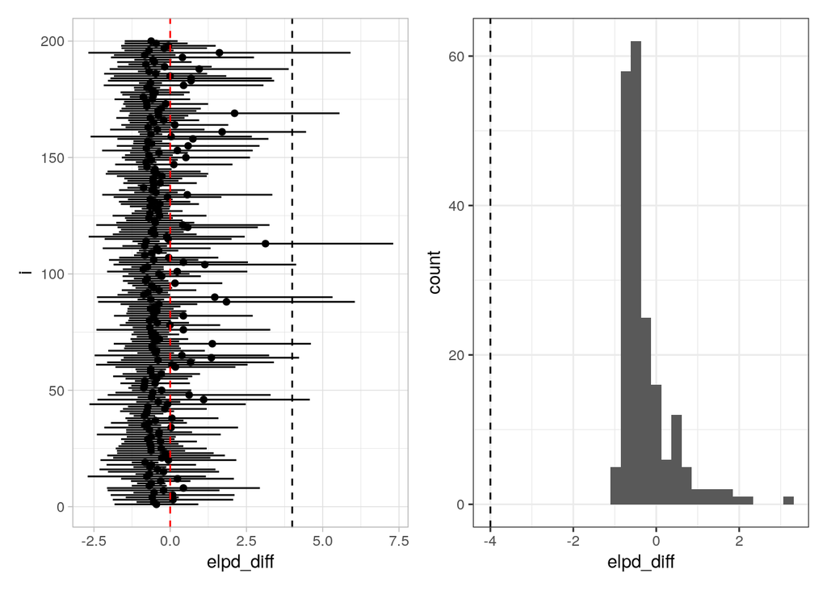

```r
anpan_loo_res = function(sigma_phylo = 0 ) {
  # set.seed(123)

  n = 120
  sigma_resid = 1

  tr = ape::rtree(n)
  cor_mat = ape::vcv.phylo(tr, corr = TRUE)

  cor_mat[1:5,1:5]
  covariate = rnorm(n)

  linear_term = 1 * covariate + rnorm(n, mean = 0, sd = sigma_resid)

  true_phylo_effects = sigma_phylo * MASS::mvrnorm(1, mu = rep(0, n), Sigma = cor_mat)

  metadata = tibble(sample_id = colnames(cor_mat),
                    covariate = covariate,
                    outcome   = linear_term + true_phylo_effects)
  result = anpan_pglmm(meta_file       = metadata,
                       tree_file       = tr,
                       outcome         = "outcome",
                       covariates      = "covariate",
                       family          = "gaussian",
                       bug_name        = "sim_bug",
                       reg_noise       = TRUE,
                       loo_comparison  = TRUE,
                       run_diagnostics = FALSE,
                       refresh         = 0,
                       parallel_chains = 4,
                       show_plot_tree  = FALSE,
                       show_post       = FALSE, verbose = FALSE)

  comp_mat = result$loo$comparison

  if (rownames(comp_mat)[2] == "base_fit"){
    comp_mat[2,1] = -1 * comp_mat[2,1]
  }

  tibble(elpd_diff = comp_mat[2,1],
         elpd_se = comp_mat[2,2])
}

#This is slow to run, so I have saved the results of the simulation
#sim_df = replicate(100, anpan_loo_res(), simplify = FALSE) |>
#  bind_rows()
#write_tsv(sim_df, "simulation_results.tsv")
sim_df = read_tsv("simulation_results.tsv")
sim_df |>
  mutate(i = 1:200) |>
  ggplot(aes(x = elpd_diff, y = i)) +
  geom_point() +
  geom_segment(aes(x = elpd_diff - 2*elpd_se,
                   xend = elpd_diff + 2*elpd_se,
                   yend = i)) +
  theme_light() + geom_vline(xintercept = 4, linetype=2) + geom_vline(xintercept = 0, linetype=2, color = 'red') -> P1
sim_df %>% ggplot(aes(x=elpd_diff)) + geom_histogram() +theme_bw() + geom_vline(xintercept = -4, linetype=2) -> P2

P1 + P2
```

Check normality - It does not seem to be completely well behaved

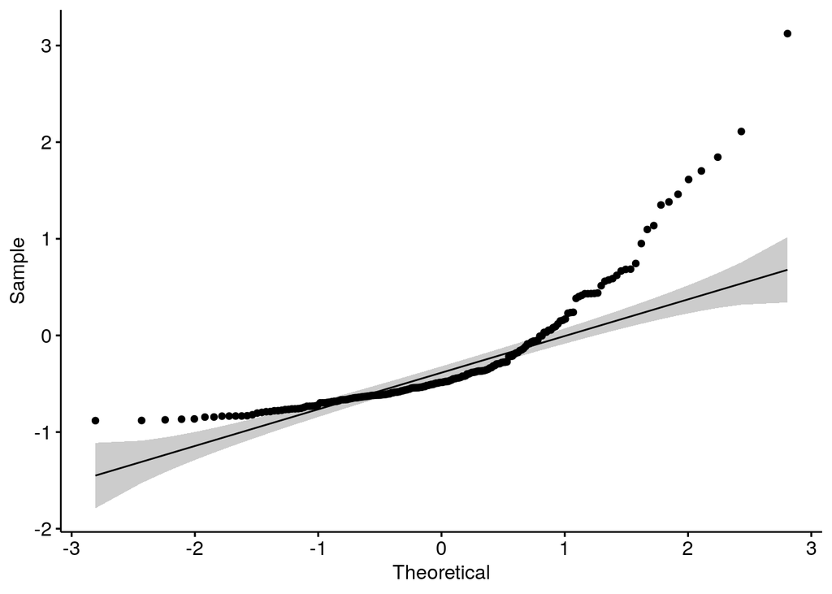

```r
library("ggpubr")
ggqqplot(sim_df$elpd_diff)
```

```r
shapiro.test(sim_df$elpd_diff)
```

```
##
##  Shapiro-Wilk normality test
##
## data:  sim_df$elpd_diff
## W = 0.76432, p-value < 2.2e-16
```

```r
sim_df %>% mutate(T_stat = elpd_diff/elpd_se, P_value = T_stat_P(T_stat), P_bonferroni = P_value*dim(sim_df)[1], FDR=p.adjust(P_value, "fdr")  ) %>% arrange(elpd_diff)
```

| elpd_diff | elpd_se | T_stat | P_value | P_bonferroni | FDR |
| --- | --- | --- | --- | --- | --- |
| -0.881853485 | 0.3358473 | -2.625756894 | 8.645654e-03 | 1.729131e+00 | 0.0617546723 |
| -0.880266789 | 0.2217093 | -3.970365056 | 7.176259e-05 | 1.435252e-02 | 0.0022880599 |
| -0.873464963 | 0.2645294 | -3.301958573 | 9.601225e-04 | 1.920245e-01 | 0.0120015312 |
| -0.867016385 | 0.2520210 | -3.440253884 | 5.811687e-04 | 1.162337e-01 | 0.0085799692 |
| -0.864164317 | 0.4312297 | -2.003953596 | 4.507503e-02 | 9.015006e+00 | 0.1918086445 |
| -0.845186000 | 0.2142883 | -3.944154261 | 8.008210e-05 | 1.601642e-02 | 0.0022880599 |
| -0.844310541 | 0.1757314 | -4.804551770 | 1.550986e-06 | 3.101971e-04 | 0.0001033990 |
| -0.835435394 | 0.2696865 | -3.097801583 | 1.949619e-03 | 3.899238e-01 | 0.0205223066 |
| -0.834601277 | 0.3658505 | -2.281263057 | 2.253289e-02 | 4.506577e+00 | 0.1287593452 |
| -0.834013604 | 0.1757742 | -4.744801714 | 2.087107e-06 | 4.174214e-04 | 0.0001043553 |

[output cut: 190 more lines]

Now, we will do the simulations when the phylogenetic signal is > 0 :

```r
#sim_df_postiive = do.call( rbind, seq(1,100) %>% lapply( function(x){
#  #List_effect = c(0.2, 0.5, 0.8, 0.8, 1, 1, 1.5, 2, 2, 3)
#    Phylo_effect = sample(size =  1, c(1, 1.5, 2, 3.5, 3, 0.5, 0.2, 0.8 ) )
#    #Phylo_effect = List_effect[x]
#  anpan_loo_res(Phylo_effect) -> Res
#  Res %>% mutate( Sim = x, Phylo_effect = Phylo_effect) -> Res
#  return(Res)
# } ) )

#write_tsv(sim_df_postiive, "simulation_results_positive.tsv")
sim_df_postiive = read_tsv("simulation_results_positive.tsv")
```

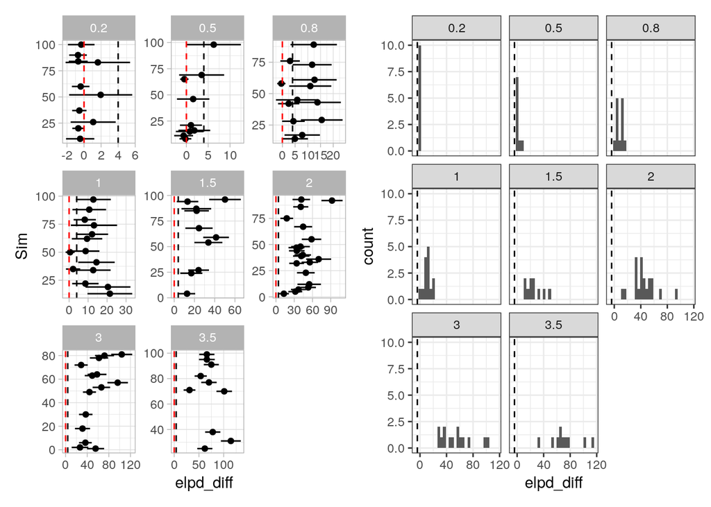

```r
sim_df_postiive %>%  ggplot(aes(x = elpd_diff, y = Sim )) +
  geom_point() +
  geom_segment(aes(x = elpd_diff - 2*elpd_se,
                   xend = elpd_diff + 2*elpd_se,
                   yend = Sim )) +
  theme_light() + geom_vline(xintercept = 4, linetype=2) + geom_vline(xintercept = 0, linetype=2, color = 'red') + facet_wrap(~as.factor(Phylo_effect), scales = 'free')   -> P1
sim_df_postiive %>% ggplot(aes(x=elpd_diff)) + geom_histogram() +theme_bw() + geom_vline(xintercept = -4, linetype=2) + facet_wrap(~as.factor(Phylo_effect)) -> P2
P1 | P2
```

## Phenotype Permutations and sigma estimation

Previously we showed that sigma_phylo was estimated in the model and corresponded with the term that multiplied to the similarity between strains:  
`true_phylo_effects = sigma_phylo * MASS::mvrnorm(1, mu = rep(0, n), Sigma = cor_mat)`. By repeating all associations while permuting the phenotypes we can get an idea about the null distribution of this term.  
All sigma results have been merged in a table, which we will compare to the acutal sigma obtained in the models.

```r
Sigma_null = read_tsv('/mnt/project/Make_Associations/Association/Null_Sigma.tsv')
```

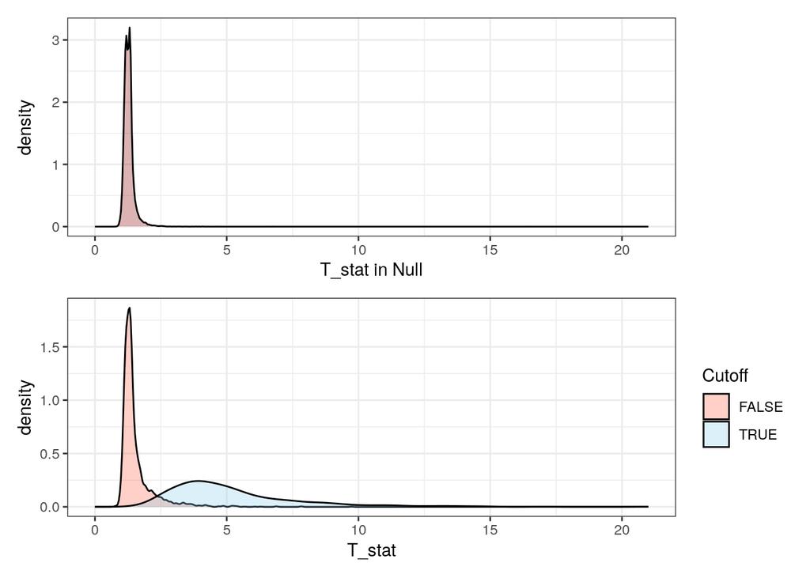

```r
Sigma_null %>%  mutate(ID_assocaition = paste0(Phenotype,"-",SGB), .before=1 )  %>% mutate(ID_assocaition2 = paste0(Phenotype,"-",SGB, '-', Continent), .before=1 ) %>% mutate(T_stat=mean/sd )-> Sigma_null
df %>% mutate(ID_assocaition = paste0(Phenotype,"-",SGB), .before=1 ) %>% mutate(ID_assocaition2 = paste0(Phenotype,"-",SGB, '-', Continent), .before=1 ) %>% mutate(T_stat=phylo_mean/phylo_sd ) -> df


ggplot() + geom_density(data = Sigma_null, aes( x=T_stat ), alpha=0.3, fill = "darkred" ) + theme_bw() + xlim(0, 21)  + xlab('T_stat in Null') -> Null
ggplot() + geom_density(data = df, aes( x=T_stat, fill=Cutoff ), alpha=0.3 )  + scale_fill_manual(values = c('TRUE'='skyblue','FALSE'= 'tomato'  ) ) + theme_bw() + xlim(0, 21) + xlab('T_stat') -> FoundValues
Null / FoundValues
```

Check per assocation how does the sigma compare to the null

```r
Get_P = function( Null, Real ){
  return( mean(Real$T_stat <= Null$T_stat) )
}
Calculated_null_Ps = function( Associations ){
  Tibble_assocation = tibble()
  for (Assocation in  Associations){
    Info = str_split(Assocation, '-')[[1]]
    #1.
    Null_association = Sigma_null %>% filter(ID_assocaition2==Assocation)
    Association = df %>% filter(ID_assocaition2==Assocation)
    P =Get_P(Null_association, Association)
    #2.
    Null_association = Sigma_null %>% filter(SGB==Info[[2]], Continent == Info[[3]] )
    P2 =Get_P(Null_association, Association)
    #3.
    Null_association = Sigma_null %>% filter( Continent == Info[[3]] )
    P3 = Get_P(Null_association, Association)

    Tibble_assocation = rbind(Tibble_assocation, tibble(Association =Assocation, P_nullAssociation=P, P_nullSGB = P2, P_nullContinent = P3  ))

  }
  return(Tibble_assocation)
}

#Significant assocations
Tibble_assocation = Calculated_null_Ps(filter(df,Cutoff==T )$ID_assocaition2 )
Tibble_assocation$P_nullAssociation %>% summary()
```

```
##    Min. 1st Qu.  Median    Mean 3rd Qu.    Max.    NA's
##       0       0       0       0       0       0     156
```

```r
Tibble_assocation$P_nullSGB %>% summary()
```

```
##    Min. 1st Qu.  Median    Mean 3rd Qu.    Max.    NA's
##  0.0000  0.0000  0.0000  0.0018  0.0000  0.2000      57
```

```r
Tibble_assocation$P_nullContinent %>% summary()
```

```
##     Min.  1st Qu.   Median     Mean  3rd Qu.     Max.
## 0.000000 0.000298 0.000596 0.001382 0.001341 0.058850
```

```r
#Non significnat associations
Tibble_noassocation =  Calculated_null_Ps(filter(df,Cutoff==F )$ID_assocaition2 )

Tibble_noassocation$P_nullAssociation %>% summary()
```

```
##    Min. 1st Qu.  Median    Mean 3rd Qu.    Max.    NA's
##  0.0000  0.0000  0.2000  0.3562  0.7000  1.0000     660
```

```r
Tibble_noassocation$P_nullSGB %>% summary()
```

```
##    Min. 1st Qu.  Median    Mean 3rd Qu.    Max.    NA's
## 0.00000 0.03333 0.25000 0.34525 0.60000 1.00000     220
```

```r
Tibble_noassocation$P_nullContinent %>% summary()
```

```
##    Min. 1st Qu.  Median    Mean 3rd Qu.    Max.    NA's
## 0.00000 0.05743 0.27551 0.35491 0.60144 1.00000      33
```